# Risk Factor Analysis

## Outcome Variable

**Outcome Variable:** haz

## Predictor Variables

**Intervention Variable:** predfeed6

**Adjustment Set:**

- arm
- sex
- month
- brthmon
- W_mage
- meducyrs
- feducyrs
- hhwealth_quart
- hfoodsec
- W_mhtcm
- W_mwtkg
- W_mbmi
- vagbrth
- W_gagebrth
- W_birthwt
- W_birthlen
- W_nrooms
- W_nchldlt5
- W_parity
- impfloor
- impsan
- safeh20
- delta_W_mage
- delta_meducyrs
- delta_feducyrs
- delta_hhwealth_quart
- delta_hfoodsec
- delta_W_mhtcm
- delta_W_mwtkg
- delta_W_mbmi
- delta_vagbrth
- delta_W_gagebrth
- delta_W_birthwt
- delta_W_birthlen
- delta_W_nrooms
- delta_W_nchldlt5
- delta_W_parity
- delta_impfloor
- delta_impsan
- delta_safeh20

## Stratifying Variables

The analysis was stratified on these variable(s):

- agecat
- studyid
- country

## Data Summary

| agecat | studyid | country | predfeed6 | n_cell | n | outcome_variable |
| --- | --- | --- | --- | --- | --- | --- |
| Birth | EE | PAKISTAN | 1 | 38 | 42 | haz |
| Birth | EE | PAKISTAN | 0 | 4 | 42 | haz |
| Birth | GMS-Nepal | NEPAL | 1 | 419 | 563 | haz |
| Birth | GMS-Nepal | NEPAL | 0 | 144 | 563 | haz |
| Birth | JiVitA-3 | BANGLADESH | 1 | 10466 | 13423 | haz |
| Birth | JiVitA-3 | BANGLADESH | 0 | 2957 | 13423 | haz |
| Birth | JiVitA-4 | BANGLADESH | 1 | 2103 | 2632 | haz |
| Birth | JiVitA-4 | BANGLADESH | 0 | 529 | 2632 | haz |
| Birth | MAL-ED | BANGLADESH | 1 | 72 | 205 | haz |
| Birth | MAL-ED | BANGLADESH | 0 | 133 | 205 | haz |
| Birth | MAL-ED | BRAZIL | 1 | 6 | 60 | haz |
| Birth | MAL-ED | BRAZIL | 0 | 54 | 60 | haz |
| Birth | MAL-ED | INDIA | 1 | 4 | 39 | haz |
| Birth | MAL-ED | INDIA | 0 | 35 | 39 | haz |
| Birth | MAL-ED | NEPAL | 1 | 3 | 24 | haz |
| Birth | MAL-ED | NEPAL | 0 | 21 | 24 | haz |
| Birth | MAL-ED | PERU | 1 | 73 | 213 | haz |
| Birth | MAL-ED | PERU | 0 | 140 | 213 | haz |
| Birth | MAL-ED | SOUTH AFRICA | 1 | 1 | 91 | haz |
| Birth | MAL-ED | SOUTH AFRICA | 0 | 90 | 91 | haz |
| Birth | MAL-ED | TANZANIA, UNITED REPUBLIC OF | 1 | 0 | 113 | haz |
| Birth | MAL-ED | TANZANIA, UNITED REPUBLIC OF | 0 | 113 | 113 | haz |
| 6 months | EE | PAKISTAN | 1 | 43 | 48 | haz |
| 6 months | EE | PAKISTAN | 0 | 5 | 48 | haz |
| 6 months | GMS-Nepal | NEPAL | 1 | 406 | 547 | haz |
| 6 months | GMS-Nepal | NEPAL | 0 | 141 | 547 | haz |
| 6 months | JiVitA-3 | BANGLADESH | 1 | 7644 | 9901 | haz |
| 6 months | JiVitA-3 | BANGLADESH | 0 | 2257 | 9901 | haz |
| 6 months | JiVitA-4 | BANGLADESH | 1 | 3328 | 4272 | haz |
| 6 months | JiVitA-4 | BANGLADESH | 0 | 944 | 4272 | haz |
| 6 months | LCNI-5 | MALAWI | 1 | 47 | 272 | haz |
| 6 months | LCNI-5 | MALAWI | 0 | 225 | 272 | haz |
| 6 months | MAL-ED | BANGLADESH | 1 | 84 | 231 | haz |
| 6 months | MAL-ED | BANGLADESH | 0 | 147 | 231 | haz |
| 6 months | MAL-ED | BRAZIL | 1 | 30 | 209 | haz |
| 6 months | MAL-ED | BRAZIL | 0 | 179 | 209 | haz |
| 6 months | MAL-ED | INDIA | 1 | 11 | 218 | haz |
| 6 months | MAL-ED | INDIA | 0 | 207 | 218 | haz |
| 6 months | MAL-ED | NEPAL | 1 | 12 | 225 | haz |
| 6 months | MAL-ED | NEPAL | 0 | 213 | 225 | haz |
| 6 months | MAL-ED | PERU | 1 | 92 | 271 | haz |
| 6 months | MAL-ED | PERU | 0 | 179 | 271 | haz |
| 6 months | MAL-ED | SOUTH AFRICA | 1 | 3 | 233 | haz |
| 6 months | MAL-ED | SOUTH AFRICA | 0 | 230 | 233 | haz |
| 6 months | MAL-ED | TANZANIA, UNITED REPUBLIC OF | 1 | 1 | 232 | haz |
| 6 months | MAL-ED | TANZANIA, UNITED REPUBLIC OF | 0 | 231 | 232 | haz |
| 6 months | SAS-FoodSuppl | INDIA | 1 | 0 | 168 | haz |
| 6 months | SAS-FoodSuppl | INDIA | 0 | 168 | 168 | haz |
| 24 months | EE | PAKISTAN | 1 | 20 | 23 | haz |
| 24 months | EE | PAKISTAN | 0 | 3 | 23 | haz |
| 24 months | GMS-Nepal | NEPAL | 1 | 356 | 470 | haz |
| 24 months | GMS-Nepal | NEPAL | 0 | 114 | 470 | haz |
| 24 months | JiVitA-3 | BANGLADESH | 1 | 3926 | 5088 | haz |
| 24 months | JiVitA-3 | BANGLADESH | 0 | 1162 | 5088 | haz |
| 24 months | JiVitA-4 | BANGLADESH | 1 | 3292 | 4199 | haz |
| 24 months | JiVitA-4 | BANGLADESH | 0 | 907 | 4199 | haz |
| 24 months | LCNI-5 | MALAWI | 1 | 34 | 189 | haz |
| 24 months | LCNI-5 | MALAWI | 0 | 155 | 189 | haz |
| 24 months | MAL-ED | BANGLADESH | 1 | 76 | 205 | haz |
| 24 months | MAL-ED | BANGLADESH | 0 | 129 | 205 | haz |
| 24 months | MAL-ED | BRAZIL | 1 | 25 | 169 | haz |
| 24 months | MAL-ED | BRAZIL | 0 | 144 | 169 | haz |
| 24 months | MAL-ED | INDIA | 1 | 11 | 209 | haz |
| 24 months | MAL-ED | INDIA | 0 | 198 | 209 | haz |
| 24 months | MAL-ED | NEPAL | 1 | 12 | 219 | haz |
| 24 months | MAL-ED | NEPAL | 0 | 207 | 219 | haz |
| 24 months | MAL-ED | PERU | 1 | 68 | 201 | haz |
| 24 months | MAL-ED | PERU | 0 | 133 | 201 | haz |
| 24 months | MAL-ED | SOUTH AFRICA | 1 | 3 | 216 | haz |
| 24 months | MAL-ED | SOUTH AFRICA | 0 | 213 | 216 | haz |
| 24 months | MAL-ED | TANZANIA, UNITED REPUBLIC OF | 1 | 1 | 202 | haz |
| 24 months | MAL-ED | TANZANIA, UNITED REPUBLIC OF | 0 | 201 | 202 | haz |

The following strata were considered:

- agecat: 24 months, studyid: EE, country: PAKISTAN
- agecat: 24 months, studyid: GMS-Nepal, country: NEPAL
- agecat: 24 months, studyid: JiVitA-3, country: BANGLADESH
- agecat: 24 months, studyid: JiVitA-4, country: BANGLADESH
- agecat: 24 months, studyid: LCNI-5, country: MALAWI
- agecat: 24 months, studyid: MAL-ED, country: BANGLADESH
- agecat: 24 months, studyid: MAL-ED, country: BRAZIL
- agecat: 24 months, studyid: MAL-ED, country: INDIA
- agecat: 24 months, studyid: MAL-ED, country: NEPAL
- agecat: 24 months, studyid: MAL-ED, country: PERU
- agecat: 24 months, studyid: MAL-ED, country: SOUTH AFRICA
- agecat: 24 months, studyid: MAL-ED, country: TANZANIA, UNITED REPUBLIC OF
- agecat: 6 months, studyid: EE, country: PAKISTAN
- agecat: 6 months, studyid: GMS-Nepal, country: NEPAL
- agecat: 6 months, studyid: JiVitA-3, country: BANGLADESH
- agecat: 6 months, studyid: JiVitA-4, country: BANGLADESH
- agecat: 6 months, studyid: LCNI-5, country: MALAWI
- agecat: 6 months, studyid: MAL-ED, country: BANGLADESH
- agecat: 6 months, studyid: MAL-ED, country: BRAZIL
- agecat: 6 months, studyid: MAL-ED, country: INDIA
- agecat: 6 months, studyid: MAL-ED, country: NEPAL
- agecat: 6 months, studyid: MAL-ED, country: PERU
- agecat: 6 months, studyid: MAL-ED, country: SOUTH AFRICA
- agecat: 6 months, studyid: MAL-ED, country: TANZANIA, UNITED REPUBLIC OF
- agecat: 6 months, studyid: SAS-FoodSuppl, country: INDIA
- agecat: Birth, studyid: EE, country: PAKISTAN
- agecat: Birth, studyid: GMS-Nepal, country: NEPAL
- agecat: Birth, studyid: JiVitA-3, country: BANGLADESH
- agecat: Birth, studyid: JiVitA-4, country: BANGLADESH
- agecat: Birth, studyid: MAL-ED, country: BANGLADESH
- agecat: Birth, studyid: MAL-ED, country: BRAZIL
- agecat: Birth, studyid: MAL-ED, country: INDIA
- agecat: Birth, studyid: MAL-ED, country: NEPAL
- agecat: Birth, studyid: MAL-ED, country: PERU
- agecat: Birth, studyid: MAL-ED, country: SOUTH AFRICA
- agecat: Birth, studyid: MAL-ED, country: TANZANIA, UNITED REPUBLIC OF

### Dropped Strata

Some strata were dropped due to rare outcomes:

- agecat: Birth, studyid: EE, country: PAKISTAN
- agecat: Birth, studyid: MAL-ED, country: INDIA
- agecat: Birth, studyid: MAL-ED, country: NEPAL
- agecat: Birth, studyid: MAL-ED, country: SOUTH AFRICA
- agecat: Birth, studyid: MAL-ED, country: TANZANIA, UNITED REPUBLIC OF
- agecat: 6 months, studyid: MAL-ED, country: SOUTH AFRICA
- agecat: 6 months, studyid: MAL-ED, country: TANZANIA, UNITED REPUBLIC OF
- agecat: 6 months, studyid: SAS-FoodSuppl, country: INDIA
- agecat: 24 months, studyid: EE, country: PAKISTAN
- agecat: 24 months, studyid: MAL-ED, country: SOUTH AFRICA
- agecat: 24 months, studyid: MAL-ED, country: TANZANIA, UNITED REPUBLIC OF

## Methods Detail

We’re interested in the causal parameters $E[Y_a]$ for all values of $a \in \mathcal{A}$. These parameters represent the mean outcome if, possibly contrary to fact, we intervened to set all units to have $A=a$. Under the randomization and positivity assumptions, these are identified by the statistical parameters $\psi_a=E_W[E_{Y|A,W}(Y|A=a,W)]$. In addition, we’re interested in the mean of $Y$, $E[Y]$ under no intervention (the observed mean). We will estimate these parameters by using SuperLearner to fit the relevant likelihood factors – $E_{Y|A,W}(Y|A=a,W)$ and $p(A=a|W)$, and then updating our likelihood fit using a joint TMLE.

For unadjusted analyses ($W=\{\}$), initial likelihoods were estimated using Lrnr_glm to estimate the simple $E(Y|A)$ and Lrnr_mean to estimate $p(A)$. For adjusted analyses, a small library containing Lrnr_glmnet, Lrnr_xgboost, and Lrnr_mean was used.

Having estimated these parameters, we will then use the delta method to estimate relative risks and attributable risks relative to a prespecified baseline level of $A$.

# Results Detail

## Results Plots

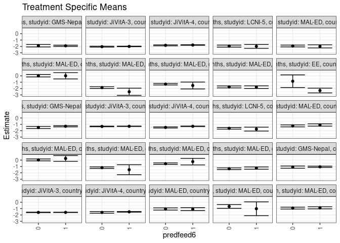

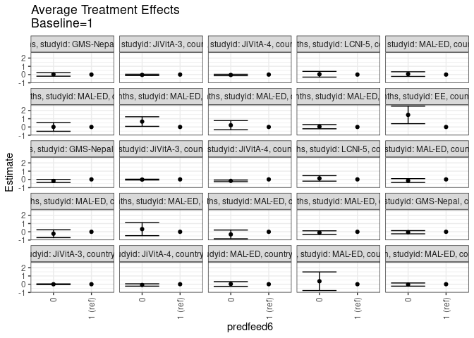

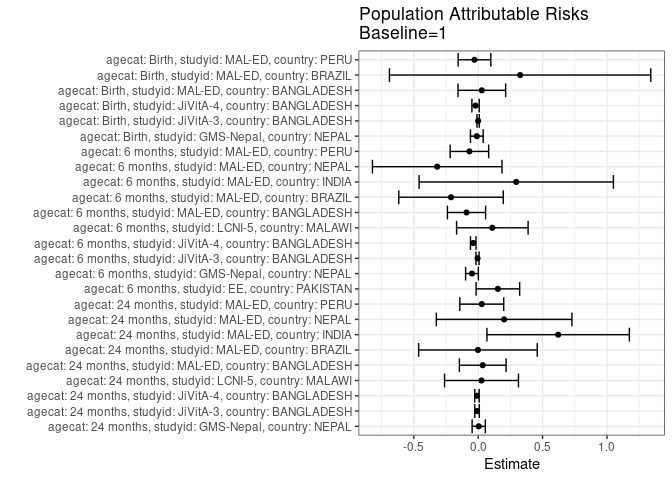

## Results Table

### Parameter: TSM

| agecat | studyid | country | intervention_level | baseline_level | estimate | ci_lower | ci_upper |
| --- | --- | --- | --- | --- | --- | --- | --- |
| Birth | GMS-Nepal | NEPAL | 1 | NA | -1.0532290 | -1.1504466 | -0.9560115 |
| Birth | GMS-Nepal | NEPAL | 0 | NA | -1.1039039 | -1.2788005 | -0.9290074 |
| Birth | JiVitA-3 | BANGLADESH | 1 | NA | -1.5948276 | -1.6195991 | -1.5700561 |
| Birth | JiVitA-3 | BANGLADESH | 0 | NA | -1.5981034 | -1.6373530 | -1.5588539 |
| Birth | JiVitA-4 | BANGLADESH | 1 | NA | -1.5066256 | -1.5587504 | -1.4545008 |
| Birth | JiVitA-4 | BANGLADESH | 0 | NA | -1.6005346 | -1.7330956 | -1.4679735 |
| Birth | MAL-ED | BANGLADESH | 1 | NA | -1.0811744 | -1.3038389 | -0.8585099 |
| Birth | MAL-ED | BANGLADESH | 0 | NA | -1.0572870 | -1.2337248 | -0.8808493 |
| Birth | MAL-ED | BRAZIL | 1 | NA | -1.0216667 | -2.1085384 | 0.0652051 |
| Birth | MAL-ED | BRAZIL | 0 | NA | -0.6601852 | -0.9595686 | -0.3608018 |
| Birth | MAL-ED | PERU | 1 | NA | -0.8775718 | -1.0419795 | -0.7131641 |
| Birth | MAL-ED | PERU | 0 | NA | -0.9216333 | -1.0686415 | -0.7746250 |
| 6 months | EE | PAKISTAN | 1 | NA | -2.3121318 | -2.6865239 | -1.9377397 |
| 6 months | EE | PAKISTAN | 0 | NA | -0.8473333 | -1.8424880 | 0.1478213 |
| 6 months | GMS-Nepal | NEPAL | 1 | NA | -1.3056083 | -1.3947138 | -1.2165028 |
| 6 months | GMS-Nepal | NEPAL | 0 | NA | -1.4916647 | -1.6608643 | -1.3224650 |
| 6 months | JiVitA-3 | BANGLADESH | 1 | NA | -1.3084890 | -1.3389147 | -1.2780633 |
| 6 months | JiVitA-3 | BANGLADESH | 0 | NA | -1.3328869 | -1.3822185 | -1.2835553 |
| 6 months | JiVitA-4 | BANGLADESH | 1 | NA | -1.3095218 | -1.3503925 | -1.2686511 |
| 6 months | JiVitA-4 | BANGLADESH | 0 | NA | -1.4867299 | -1.5777019 | -1.3957579 |
| 6 months | LCNI-5 | MALAWI | 1 | NA | -1.7493228 | -2.0539948 | -1.4446508 |
| 6 months | LCNI-5 | MALAWI | 0 | NA | -1.6268810 | -1.7581336 | -1.4956283 |
| 6 months | MAL-ED | BANGLADESH | 1 | NA | -1.0991848 | -1.2783319 | -0.9200377 |
| 6 months | MAL-ED | BANGLADESH | 0 | NA | -1.2439491 | -1.3985812 | -1.0893170 |
| 6 months | MAL-ED | BRAZIL | 1 | NA | 0.2588641 | -0.1903787 | 0.7081068 |
| 6 months | MAL-ED | BRAZIL | 0 | NA | 0.0301650 | -0.1196332 | 0.1799632 |
| 6 months | MAL-ED | INDIA | 1 | NA | -1.5142805 | -2.3005637 | -0.7279972 |
| 6 months | MAL-ED | INDIA | 0 | NA | -1.1880902 | -1.3089085 | -1.0672718 |
| 6 months | MAL-ED | NEPAL | 1 | NA | -0.2436884 | -0.7585695 | 0.2711927 |
| 6 months | MAL-ED | NEPAL | 0 | NA | -0.5574784 | -0.6758674 | -0.4390894 |
| 6 months | MAL-ED | PERU | 1 | NA | -1.2536318 | -1.4326704 | -1.0745931 |
| 6 months | MAL-ED | PERU | 0 | NA | -1.3559390 | -1.4913966 | -1.2204814 |
| 24 months | GMS-Nepal | NEPAL | 1 | NA | -1.9040889 | -1.9991037 | -1.8090741 |
| 24 months | GMS-Nepal | NEPAL | 0 | NA | -1.8884171 | -2.0810345 | -1.6957996 |
| 24 months | JiVitA-3 | BANGLADESH | 1 | NA | -2.0025432 | -2.0425096 | -1.9625767 |
| 24 months | JiVitA-3 | BANGLADESH | 0 | NA | -2.0432876 | -2.1130633 | -1.9735118 |
| 24 months | JiVitA-4 | BANGLADESH | 1 | NA | -1.7815254 | -1.8233236 | -1.7397273 |
| 24 months | JiVitA-4 | BANGLADESH | 0 | NA | -1.8293405 | -1.9056841 | -1.7529968 |
| 24 months | LCNI-5 | MALAWI | 1 | NA | -1.9906369 | -2.2987408 | -1.6825330 |
| 24 months | LCNI-5 | MALAWI | 0 | NA | -1.9516140 | -2.1105003 | -1.7927277 |
| 24 months | MAL-ED | BANGLADESH | 1 | NA | -1.9925865 | -2.2371292 | -1.7480439 |
| 24 months | MAL-ED | BANGLADESH | 0 | NA | -1.9331285 | -2.0780761 | -1.7881808 |
| 24 months | MAL-ED | BRAZIL | 1 | NA | 0.0081380 | -0.4858666 | 0.5021426 |
| 24 months | MAL-ED | BRAZIL | 0 | NA | 0.0153519 | -0.1711083 | 0.2018120 |
| 24 months | MAL-ED | INDIA | 1 | NA | -2.5071687 | -3.0747425 | -1.9395950 |
| 24 months | MAL-ED | INDIA | 0 | NA | -1.8515871 | -1.9833002 | -1.7198740 |
| 24 months | MAL-ED | NEPAL | 1 | NA | -1.5199765 | -2.0602381 | -0.9797150 |
| 24 months | MAL-ED | NEPAL | 0 | NA | -1.3058656 | -1.4312702 | -1.1804610 |
| 24 months | MAL-ED | PERU | 1 | NA | -1.7799441 | -1.9850810 | -1.5748072 |
| 24 months | MAL-ED | PERU | 0 | NA | -1.7425438 | -1.8933843 | -1.5917033 |

### Parameter: E(Y)

| agecat | studyid | country | intervention_level | baseline_level | estimate | ci_lower | ci_upper |
| --- | --- | --- | --- | --- | --- | --- | --- |
| Birth | GMS-Nepal | NEPAL | NA | NA | -1.0641208 | -1.1525364 | -0.9757052 |
| Birth | JiVitA-3 | BANGLADESH | NA | NA | -1.5955338 | -1.6186322 | -1.5724354 |
| Birth | JiVitA-4 | BANGLADESH | NA | NA | -1.5273138 | -1.5765339 | -1.4780937 |
| Birth | MAL-ED | BANGLADESH | NA | NA | -1.0530244 | -1.1913751 | -0.9146736 |
| Birth | MAL-ED | BRAZIL | NA | NA | -0.6963333 | -0.9881882 | -0.4044785 |
| Birth | MAL-ED | PERU | NA | NA | -0.9065728 | -1.0297267 | -0.7834188 |
| 6 months | EE | PAKISTAN | NA | NA | -2.1595486 | -2.5331781 | -1.7859192 |
| 6 months | GMS-Nepal | NEPAL | NA | NA | -1.3540280 | -1.4334801 | -1.2745760 |
| 6 months | JiVitA-3 | BANGLADESH | NA | NA | -1.3138259 | -1.3418712 | -1.2857806 |
| 6 months | JiVitA-4 | BANGLADESH | NA | NA | -1.3482303 | -1.3866421 | -1.3098185 |
| 6 months | LCNI-5 | MALAWI | NA | NA | -1.6395956 | -1.7592633 | -1.5199278 |
| 6 months | MAL-ED | BANGLADESH | NA | NA | -1.1900794 | -1.3096296 | -1.0705291 |
| 6 months | MAL-ED | BRAZIL | NA | NA | 0.0475758 | -0.0963508 | 0.1915023 |
| 6 months | MAL-ED | INDIA | NA | NA | -1.2188303 | -1.3423090 | -1.0953516 |
| 6 months | MAL-ED | NEPAL | NA | NA | -0.5622370 | -0.6774081 | -0.4470660 |
| 6 months | MAL-ED | PERU | NA | NA | -1.3220326 | -1.4308168 | -1.2132484 |
| 24 months | GMS-Nepal | NEPAL | NA | NA | -1.9002128 | -1.9869255 | -1.8135001 |
| 24 months | JiVitA-3 | BANGLADESH | NA | NA | -2.0118003 | -2.0479952 | -1.9756055 |
| 24 months | JiVitA-4 | BANGLADESH | NA | NA | -1.7914765 | -1.8297816 | -1.7531715 |
| 24 months | LCNI-5 | MALAWI | NA | NA | -1.9651323 | -2.1053230 | -1.8249415 |
| 24 months | MAL-ED | BANGLADESH | NA | NA | -1.9576341 | -2.0857597 | -1.8295086 |
| 24 months | MAL-ED | BRAZIL | NA | NA | 0.0061144 | -0.1625850 | 0.1748138 |
| 24 months | MAL-ED | INDIA | NA | NA | -1.8863397 | -2.0168508 | -1.7558287 |
| 24 months | MAL-ED | NEPAL | NA | NA | -1.3187671 | -1.4406685 | -1.1968657 |
| 24 months | MAL-ED | PERU | NA | NA | -1.7524710 | -1.8736426 | -1.6312994 |

### Parameter: ATE

| agecat | studyid | country | intervention_level | baseline_level | estimate | ci_lower | ci_upper |
| --- | --- | --- | --- | --- | --- | --- | --- |
| Birth | GMS-Nepal | NEPAL | 1 | 1 | 0.0000000 | 0.0000000 | 0.0000000 |
| Birth | GMS-Nepal | NEPAL | 0 | 1 | -0.0506749 | -0.2433031 | 0.1419534 |
| Birth | JiVitA-3 | BANGLADESH | 1 | 1 | 0.0000000 | 0.0000000 | 0.0000000 |
| Birth | JiVitA-3 | BANGLADESH | 0 | 1 | -0.0032758 | -0.0440004 | 0.0374487 |
| Birth | JiVitA-4 | BANGLADESH | 1 | 1 | 0.0000000 | 0.0000000 | 0.0000000 |
| Birth | JiVitA-4 | BANGLADESH | 0 | 1 | -0.0939089 | -0.2354288 | 0.0476109 |
| Birth | MAL-ED | BANGLADESH | 1 | 1 | 0.0000000 | 0.0000000 | 0.0000000 |
| Birth | MAL-ED | BANGLADESH | 0 | 1 | 0.0238874 | -0.2603605 | 0.3081352 |
| Birth | MAL-ED | BRAZIL | 1 | 1 | 0.0000000 | 0.0000000 | 0.0000000 |
| Birth | MAL-ED | BRAZIL | 0 | 1 | 0.3614815 | -0.7658697 | 1.4888326 |
| Birth | MAL-ED | PERU | 1 | 1 | 0.0000000 | 0.0000000 | 0.0000000 |
| Birth | MAL-ED | PERU | 0 | 1 | -0.0440615 | -0.2365847 | 0.1484617 |
| 6 months | EE | PAKISTAN | 1 | 1 | 0.0000000 | 0.0000000 | 0.0000000 |
| 6 months | EE | PAKISTAN | 0 | 1 | 1.4647984 | 0.4015477 | 2.5280492 |
| 6 months | GMS-Nepal | NEPAL | 1 | 1 | 0.0000000 | 0.0000000 | 0.0000000 |
| 6 months | GMS-Nepal | NEPAL | 0 | 1 | -0.1860564 | -0.3770219 | 0.0049091 |
| 6 months | JiVitA-3 | BANGLADESH | 1 | 1 | 0.0000000 | 0.0000000 | 0.0000000 |
| 6 months | JiVitA-3 | BANGLADESH | 0 | 1 | -0.0243979 | -0.0768229 | 0.0280271 |
| 6 months | JiVitA-4 | BANGLADESH | 1 | 1 | 0.0000000 | 0.0000000 | 0.0000000 |
| 6 months | JiVitA-4 | BANGLADESH | 0 | 1 | -0.1772081 | -0.2756143 | -0.0788019 |
| 6 months | LCNI-5 | MALAWI | 1 | 1 | 0.0000000 | 0.0000000 | 0.0000000 |
| 6 months | LCNI-5 | MALAWI | 0 | 1 | 0.1224418 | -0.2099007 | 0.4547844 |
| 6 months | MAL-ED | BANGLADESH | 1 | 1 | 0.0000000 | 0.0000000 | 0.0000000 |
| 6 months | MAL-ED | BANGLADESH | 0 | 1 | -0.1447643 | -0.3779701 | 0.0884415 |
| 6 months | MAL-ED | BRAZIL | 1 | 1 | 0.0000000 | 0.0000000 | 0.0000000 |
| 6 months | MAL-ED | BRAZIL | 0 | 1 | -0.2286991 | -0.7008614 | 0.2434633 |
| 6 months | MAL-ED | INDIA | 1 | 1 | 0.0000000 | 0.0000000 | 0.0000000 |
| 6 months | MAL-ED | INDIA | 0 | 1 | 0.3261903 | -0.4685481 | 1.1209287 |
| 6 months | MAL-ED | NEPAL | 1 | 1 | 0.0000000 | 0.0000000 | 0.0000000 |
| 6 months | MAL-ED | NEPAL | 0 | 1 | -0.3137900 | -0.8432705 | 0.2156906 |
| 6 months | MAL-ED | PERU | 1 | 1 | 0.0000000 | 0.0000000 | 0.0000000 |
| 6 months | MAL-ED | PERU | 0 | 1 | -0.1023072 | -0.3256383 | 0.1210238 |
| 24 months | GMS-Nepal | NEPAL | 1 | 1 | 0.0000000 | 0.0000000 | 0.0000000 |
| 24 months | GMS-Nepal | NEPAL | 0 | 1 | 0.0156718 | -0.1970471 | 0.2283907 |
| 24 months | JiVitA-3 | BANGLADESH | 1 | 1 | 0.0000000 | 0.0000000 | 0.0000000 |
| 24 months | JiVitA-3 | BANGLADESH | 0 | 1 | -0.0407444 | -0.1177185 | 0.0362297 |
| 24 months | JiVitA-4 | BANGLADESH | 1 | 1 | 0.0000000 | 0.0000000 | 0.0000000 |
| 24 months | JiVitA-4 | BANGLADESH | 0 | 1 | -0.0478151 | -0.1297018 | 0.0340717 |
| 24 months | LCNI-5 | MALAWI | 1 | 1 | 0.0000000 | 0.0000000 | 0.0000000 |
| 24 months | LCNI-5 | MALAWI | 0 | 1 | 0.0390229 | -0.3082251 | 0.3862710 |
| 24 months | MAL-ED | BANGLADESH | 1 | 1 | 0.0000000 | 0.0000000 | 0.0000000 |
| 24 months | MAL-ED | BANGLADESH | 0 | 1 | 0.0594581 | -0.2227328 | 0.3416490 |
| 24 months | MAL-ED | BRAZIL | 1 | 1 | 0.0000000 | 0.0000000 | 0.0000000 |
| 24 months | MAL-ED | BRAZIL | 0 | 1 | 0.0072139 | -0.5237088 | 0.5381366 |
| 24 months | MAL-ED | INDIA | 1 | 1 | 0.0000000 | 0.0000000 | 0.0000000 |
| 24 months | MAL-ED | INDIA | 0 | 1 | 0.6555816 | 0.0725902 | 1.2385731 |
| 24 months | MAL-ED | NEPAL | 1 | 1 | 0.0000000 | 0.0000000 | 0.0000000 |
| 24 months | MAL-ED | NEPAL | 0 | 1 | 0.2141110 | -0.3408258 | 0.7690477 |
| 24 months | MAL-ED | PERU | 1 | 1 | 0.0000000 | 0.0000000 | 0.0000000 |
| 24 months | MAL-ED | PERU | 0 | 1 | 0.0374003 | -0.2179525 | 0.2927531 |

### Parameter: PAR

| agecat | studyid | country | intervention_level | baseline_level | estimate | ci_lower | ci_upper |
| --- | --- | --- | --- | --- | --- | --- | --- |
| Birth | GMS-Nepal | NEPAL | 1 | NA | -0.0108917 | -0.0603374 | 0.0385539 |
| Birth | JiVitA-3 | BANGLADESH | 1 | NA | -0.0007062 | -0.0096704 | 0.0082581 |
| Birth | JiVitA-4 | BANGLADESH | 1 | NA | -0.0206882 | -0.0491424 | 0.0077660 |
| Birth | MAL-ED | BANGLADESH | 1 | NA | 0.0281500 | -0.1567040 | 0.2130040 |
| Birth | MAL-ED | BRAZIL | 1 | NA | 0.3253333 | -0.6896600 | 1.3403266 |
| Birth | MAL-ED | PERU | 1 | NA | -0.0290010 | -0.1559815 | 0.0979795 |
| 6 months | EE | PAKISTAN | 1 | NA | 0.1525832 | -0.0166253 | 0.3217917 |
| 6 months | GMS-Nepal | NEPAL | 1 | NA | -0.0484198 | -0.0979326 | 0.0010931 |
| 6 months | JiVitA-3 | BANGLADESH | 1 | NA | -0.0053369 | -0.0172663 | 0.0065926 |
| 6 months | JiVitA-4 | BANGLADESH | 1 | NA | -0.0387086 | -0.0600847 | -0.0173325 |
| 6 months | LCNI-5 | MALAWI | 1 | NA | 0.1097272 | -0.1679802 | 0.3874346 |
| 6 months | MAL-ED | BANGLADESH | 1 | NA | -0.0908946 | -0.2391689 | 0.0573798 |
| 6 months | MAL-ED | BRAZIL | 1 | NA | -0.2112883 | -0.6171564 | 0.1945798 |
| 6 months | MAL-ED | INDIA | 1 | NA | 0.2954502 | -0.4590941 | 1.0499945 |
| 6 months | MAL-ED | NEPAL | 1 | NA | -0.3185486 | -0.8215526 | 0.1844554 |
| 6 months | MAL-ED | PERU | 1 | NA | -0.0684008 | -0.2177927 | 0.0809911 |
| 24 months | GMS-Nepal | NEPAL | 1 | NA | 0.0038761 | -0.0473194 | 0.0550716 |
| 24 months | JiVitA-3 | BANGLADESH | 1 | NA | -0.0092572 | -0.0269312 | 0.0084169 |
| 24 months | JiVitA-4 | BANGLADESH | 1 | NA | -0.0099511 | -0.0273118 | 0.0074095 |
| 24 months | LCNI-5 | MALAWI | 1 | NA | 0.0255046 | -0.2616236 | 0.3126329 |
| 24 months | MAL-ED | BANGLADESH | 1 | NA | 0.0349524 | -0.1464428 | 0.2163476 |
| 24 months | MAL-ED | BRAZIL | 1 | NA | -0.0020236 | -0.4626408 | 0.4585937 |
| 24 months | MAL-ED | INDIA | 1 | NA | 0.6208290 | 0.0675971 | 1.1740609 |
| 24 months | MAL-ED | NEPAL | 1 | NA | 0.2012094 | -0.3253828 | 0.7278016 |
| 24 months | MAL-ED | PERU | 1 | NA | 0.0274731 | -0.1430723 | 0.1980185 |